# SI 618: Natural Language Processing

# Why learn NLP?

- Natural language = human language
- We use language to learn about the world
- How machines understand human langauge?
- How can we quantify the meaning of language?

## Applications?

- Probabily any service that uses text as information
- Search engine, SNS
  - What's the document about?
  - How do you determine the similarity?
- Virtual assistants: Alexa, Google Assistant, Cortana, etc.
  - Understand the semantic information from your speech from parsed text
- Biology, genetics
  - Genetic information / DNA sequence as text
  - Draw networks of proteins/molecules from vast amount of scientific papers

# Outline for today

- `spaCy`
  - Cleaning the data
  - Extracting linguistic features
- `Word2Vec`
  - Vector representation of words
  - Word similarities
  - Vector algebra for semantics

```python
import pandas as pd
import numpy as np
import re
import seaborn as sns
import matplotlib.pyplot as plt
%matplotlib inline
```

# spaCy?

- Fast, and extensible NLP package for Python
- https://spacy.io/

```python
!pip install spacy
```

[output not shown]

```python
# ! conda install -y spacy
```

```python
import spacy
```

```python
! python -m spacy download en
```

```
    100% |████████████████████████████████| 37.4MB 14.3MB/s
  Running setup.py install for en-core-web-sm ... done

    Linking successful
    /anaconda3/envs/si618/lib/python3.6/site-packages/en_core_web_sm -->
    /anaconda3/envs/si618/lib/python3.6/site-packages/spacy/data/en

    You can now load the model via spacy.load('en')
```

```python
# loading up the language model: English
nlp = spacy.load('en')
```

# 0. Data cleaning

```python
# from https://en.wikipedia.org/wiki/Portal:History
sentences = """History (from Greek ἱστορία, historia, meaning "inquiry, knowledge acquired by investigation") is the study of the past as it is described in written documents. Events occurring before written record are considered prehistory. It is an umbrella term that relates to past events as well as the memory, discovery, collection, organization, presentation, and interpretation of information about these events. Scholars who write about history are called historians.

History can also refer to the academic discipline which uses a narrative to examine and analyse a sequence of past events, and objectively determine the patterns of cause and effect that determine them. Historians sometimes debate the nature of history and its usefulness by discussing the study of the discipline as an end in itself and as a way of providing "perspective" on the problems of the present.

Stories common to a particular culture, but not supported by external sources (such as the tales surrounding King Arthur), are usually classified as cultural heritage or legends, because they do not show the "disinterested investigation" required of the discipline of history. Herodotus, a 5th-century BC Greek historian is considered within the Western tradition to be the "father of history", and, along with his contemporary Thucydides, helped form the foundations for the modern study of human history. Their works continue to be read today, and the gap between the culture-focused Herodotus and the military-focused Thucydides remains a point of contention or approach in modern historical writing. In East Asia, a state chronicle, the Spring and Autumn Annals was known to be compiled from as early as 722 BC although only 2nd-century BC texts survived.

Ancient influences have helped spawn variant interpretations of the nature of history which have evolved over the centuries and continue to change today. The modern study of history is wide-ranging, and includes the study of specific regions and the study of certain topical or thematical elements of historical investigation. Often history is taught as part of primary and secondary education, and the academic study of history is a major discipline in university studies."""
```

### Section goal: calculate the frequency of each word

- See which words are more frequent.
- Generate more meaningful summary for the above paragraph.

## 0-1. lowering the case

```python
type(sentences)
```

```
str
```

```python
sentences
```

```
'History (from Greek ἱστορία, historia, meaning "inquiry, knowledge acquired by investigation") is the study of the past as it is described in written documents. Events occurring before written record are considered prehistory. It is an umbrella term that relates to past events as well as the memory…
```

```python
sent_low = sentences.lower()
```

```python
sent_low
```

```
'history (from greek ἱστορία, historia, meaning "inquiry, knowledge acquired by investigation") is the study of the past as it is described in written documents. events occurring before written record are considered prehistory. it is an umbrella term that relates to past events as well as the memory…
```

## 0-2. remove punctuations and special characters

#### Exclude special characters one by one

```python
# from https://www.programiz.com/python-programming/examples/remove-punctuation
punctuations = '''!()-[]{};:'"\,<>./?@#$%^&*_~''' # list of special characters you want to exclude
sent_low_pnct = ""
for char in sent_low:
    if char not in punctuations:
        sent_low_pnct = sent_low_pnct + char

sent_low_pnct
```

```
'history from greek ἱστορία historia meaning inquiry knowledge acquired by investigation is the study of the past as it is described in written documents events occurring before written record are considered prehistory it is an umbrella term that relates to past events as well as the memory discover…
```

#### Alternatively, we can use regular expression to remove punctuations

- So we don't have to list up all possible special characters that we want to remove
- https://docs.python.org/3.4/library/re.html
- https://en.wikipedia.org/wiki/Regular_expression

```python
import re
sent_low_pnct2 = re.sub(r'[^\w\s]', '', sent_low)
```

```python
sent_low_pnct2
```

```
'history from greek ἱστορία historia meaning inquiry knowledge acquired by investigation is the study of the past as it is described in written documents events occurring before written record are considered prehistory it is an umbrella term that relates to past events as well as the memory discover…
```

- However, special character `\n` (linebreak) still exists in both cases. Let's remove these additionally.

```python
import os
os.linesep
# because different systems have different representations of linebreak;
# by using 'os' -> different systems would have the same results
```

```
'\n'
```

```python
sent_low_pnct = sent_low_pnct.replace(os.linesep, "")
sent_low_pnct
```

```
'history from greek ἱστορία historia meaning inquiry knowledge acquired by investigation is the study of the past as it is described in written documents events occurring before written record are considered prehistory it is an umbrella term that relates to past events as well as the memory discover…
```

### $\rightarrow$ 3 possible ways to replace characters!

### Q1. How would you remove numbers from the paragraph?

```python
remove_digits = re.sub(r'\d+', '', sent_low_pnct)
remove_digits
```

```
'history from greek ἱστορία historia meaning inquiry knowledge acquired by investigation is the study of the past as it is described in written documents events occurring before written record are considered prehistory it is an umbrella term that relates to past events as well as the memory discover…
```

```python
# put your code here
digits = '0123456789'
remove_digits = ''
for char in sent_low_pnct:
    if char not in digits:
        remove_digits += char

remove_digits
```

```
'history from greek ἱστορία historia meaning inquiry knowledge acquired by investigation is the study of the past as it is described in written documents events occurring before written record are considered prehistory it is an umbrella term that relates to past events as well as the memory discover…
```

## 0-3. Remove stop words

- Stop words usually refers to the most common words in a language
  - No single universial stopwords
  - Often stopwords are removed to improve the performance of NLP models
  - https://en.wikipedia.org/wiki/Stop_words
  - https://en.wikipedia.org/wiki/Most_common_words_in_English

#### Import the list of stop words from `spaCy`

```python
from spacy.lang.en.stop_words import STOP_WORDS
```

```python
np.array(STOP_WORDS)
```

```
array({'what', 'may', 'not', 'only', 'besides', 'himself', 'thence', 'was', 'however', 'among', 'become', 'whose', 'they', 'off', 'has', 'whether', 'hereafter', 'go', 'whenever', 'yourself', 'could', 'whither', 'will', 'would', 'four', 'its', 'show', 'two', 'thru', 'former', 'up', 'itself', 'at', 'e…
      dtype=object)
```

#### Goal: We are going to count the frequency of each word from the paragraph, to see which words can be used to represent the paragraph's content.

#### What if we do not remove stopwords?

```python
from collections import Counter
```

- Note that our paragraph is stored as a single string object...

```python
sent_low_pnct
```

```
'history from greek ἱστορία historia meaning inquiry knowledge acquired by investigation is the study of the past as it is described in written documents events occurring before written record are considered prehistory it is an umbrella term that relates to past events as well as the memory discover…
```

- Split the paragraph into a list of words

```python
words = sent_low_pnct.split()
```

- Count the words from the list
- Words that can occur in any kind of paragraphs...?

```python
Counter(words).most_common(10)  # without removing stop words
```

```
[('the', 27),
 ('of', 21),
 ('and', 15),
 ('history', 10),
 ('as', 10),
 ('to', 8),
 ('a', 8),
 ('is', 7),
 ('study', 7),
 ('in', 5)]
```

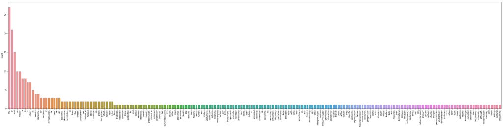

```python
plt.figure(figsize=(45,10))
sns.countplot(words, order=pd.Series(words).value_counts().index)
# sns.countplot(words_nostop, order=[counted[0] for counted in Counter(words_nostop).most_common()])
plt.xticks(rotation=90)
plt.show()
```

(double click the plot to enlarge)

#### When we removed stopwords:

```python
# split sentence into words
words_nostop = list()
for word in words:  # words --> is a list of words after the original split
    if word not in STOP_WORDS:  # remove the unmeaningful words
        words_nostop.append(word)
# words_nostop = [word for word in words if word not in STOP_WORDS]
```

- More comprehensible, and unique list or words!

```python
Counter(words_nostop).most_common(10)
```

```
[('history', 10),
 ('study', 7),
 ('events', 4),
 ('discipline', 4),
 ('investigation', 3),
 ('past', 3),
 ('bc', 3),
 ('modern', 3),
 ('greek', 2),
 ('written', 2)]
```

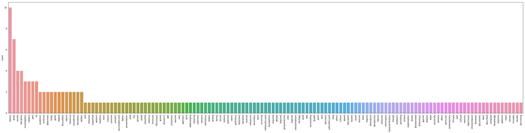

```python
plt.figure(figsize=(45,10))
sns.countplot(words_nostop, order=pd.Series(words_nostop).value_counts().index)
# sns.countplot(words_nostop, order=[counted[0] for counted in Counter(words_nostop).most_common()])
plt.xticks(rotation=90)
plt.show()
```

(double click the plot to enlarge)

### Q2. Based on the word frequency results, what was the paragraph about?

This paragraph is about academic study of history, possibly the Greek history since "Greek" appears quite frequent in the paragraph as well.

# 1. Extracting linguistic features from spaCy

## 1-1. Tokenize

- Token: a semantic unit for analysis
  - (Loosely) equal term for word
    - `sent_low_pnct.split()`
  - Tricky cases
    - aren't $\rightarrow$

[figure not shown]

      ?

[figure not shown]

      ?
    - O'Neil $\rightarrow$

[figure not shown]

      ?

[figure not shown]

      ?
    - https://nlp.stanford.edu/IR-book/html/htmledition/tokenization-1.html
- In `spaCy`:
  - Many token types, like word, puntuation symbol, whitespace, etc.

### Let's disect the sentence!

- initiating the `spaCy` object

```python
# examples partially taken from https://nlpforhackers.io/complete-guide-to-spacy/
import spacy
nlp = spacy.load('en')
```

- Our sentence: "Hello World!"
  - Pass the sentence string to the `spaCy` object `nlp`

```python
doc = nlp("Hello World!")   # O'Neil --> using Spacy would treat as a whole term
```

- The sentence is considered as a short document.

```python
print(type(doc), doc)
```

[output not shown]

- As importing the sentence string above, `spaCy` splited the sentence into tokens (tokenization!)

```python
for i,token in enumerate(doc):
    print(i, token)
```

```
0 Hello
1 World
2 !
```

- With index information (location from the sentence) of each token

| 0 | 1 | 2 | 3 | 4 | 5 | 6 | 7 | 8 | 9 | 10 | 11 |
| --- | --- | --- | --- | --- | --- | --- | --- | --- | --- | --- | --- |
| H | e | l | l | o | _ | W | o | r | l | d | ! |

```python
for i, token in enumerate(doc):
    print(i, token.text, token.idx)

# token.idx --> return the position of the first char appearing
# token --> means return meaningful term that we are interested in
```

```
0 Hello 0
1 World 6
2 ! 11
```

- And many more!
  - https://spacy.io/api/token#attributes

```python
doc = nlp("What did you do during the study break   ?")

print("text \t idx \t lemma \t lower \t is_punct \t is_space \t shape \t POS")
for token in doc:
    print("{0}\t{1}\t{2}\t{3}\t{4}\t{5}\t{6}\t{7}".format(
        token.text,
        token.idx,
        token.lemma_,
        token.lower_,
        token.is_punct,
        token.is_space,
        token.shape_,
        token.pos_
    ))
```

```
text 	 idx 	 lemma 	 lower 	 is_punct 	 is_space 	 shape 	 POS
What	0	what	what	False	False	Xxxx	NOUN
did	5	do	did	False	False	xxx	VERB
you	9	-PRON-	you	False	False	xxx	PRON
do	13	do	do	False	False	xx	VERB
during	16	during	during	False	False	xxxx	ADP
the	23	the	the	False	False	xxx	DET
study	27	study	study	False	False	xxxx	NOUN
break	33	break	break	False	False	xxxx	NOUN
  	39	  	  	False	True	  	SPACE
?	41	?	?	True	False	?	PUNCT
```

## 1-2. Sentence detection

- For the document with multiple sentences, we would need to separate between each sentences.
- In `spaCy`, the job is more convinient (and would cause less mistatkes) than using regular expression

### Q3. How would you separate sentences? What's your intuition?

(type in your response here) Split the sentences with punctuation.

- Our multiple sentence document:

```python
doc_multsent = "These are apples. Those are oranges from N.Y.C. and...? How about pineapples? Not carrots!!!"
```

- in regular expression...

```python
import re
sentences = re.split(r"(?<!\w\.\w.)(?<![A-Z][a-z]\.)(?<=\.|\?)\s", doc_multsent) # how would I remember this pattern without Google/StackOverflow?
for i, sent in enumerate(sentences):
    print(i, sent)
```

```
0 These are apples.
1 Those are oranges from N.Y.C. and...?
2 How about pineapples?
3 Not carrots!!!
```

- in `spaCy`!

```python
# same document, but initiate as the spaCy object...
doc = nlp(doc_multsent)
```

- Sentences are stored as a generator object
  - Instead of storing sentences as a list, each sentence is stored as a item in the generator object
  - Iteratable (i.e., can be used in a for loop)
  - More efficient memory use
  - https://wiki.python.org/moin/Generators

```python
doc.sents # spacy makes in convenient to deal with multi-sentences --> nlp() --> each sentence as a generator
```

```
<generator at 0x1a149d4d90>
```

- Prining sentences with the index number

```python
for i, sent in enumerate(doc.sents):
    print(i, sent)
```

```
0 These are apples.
1 Those are oranges from N.Y.C.
2 and...?
3 How about pineapples?
4 Not carrots!!!
```

### Q4. Separate sentences in the following paragraph, and print sentences with the index number.

```python
# from https://en.wikipedia.org/wiki/Portal:History
sentences = """History (from Greek ἱστορία, historia, meaning "inquiry, knowledge acquired by investigation") is the study of the past as it is described in written documents. Events occurring before written record are considered prehistory. It is an umbrella term that relates to past events as well as the memory, discovery, collection, organization, presentation, and interpretation of information about these events. Scholars who write about history are called historians.

History can also refer to the academic discipline which uses a narrative to examine and analyse a sequence of past events, and objectively determine the patterns of cause and effect that determine them. Historians sometimes debate the nature of history and its usefulness by discussing the study of the discipline as an end in itself and as a way of providing "perspective" on the problems of the present.

Stories common to a particular culture, but not supported by external sources (such as the tales surrounding King Arthur), are usually classified as cultural heritage or legends, because they do not show the "disinterested investigation" required of the discipline of history. Herodotus, a 5th-century BC Greek historian is considered within the Western tradition to be the "father of history", and, along with his contemporary Thucydides, helped form the foundations for the modern study of human history. Their works continue to be read today, and the gap between the culture-focused Herodotus and the military-focused Thucydides remains a point of contention or approach in modern historical writing. In East Asia, a state chronicle, the Spring and Autumn Annals was known to be compiled from as early as 722 BC although only 2nd-century BC texts survived.

Ancient influences have helped spawn variant interpretations of the nature of history which have evolved over the centuries and continue to change today. The modern study of history is wide-ranging, and includes the study of specific regions and the study of certain topical or thematical elements of historical investigation. Often history is taught as part of primary and secondary education, and the academic study of history is a major discipline in university studies."""
```

```python
# put your code here
doc = nlp(sentences)

for i, sent in enumerate(doc.sents):
    print(i, sent)
```

```
0 History (from Greek ἱστορία, historia, meaning "inquiry, knowledge acquired by investigation") is the study of the past as it is described in written documents.
1 Events occurring before written record are considered prehistory.
2 It is an umbrella term that relates to past events as well as the memory, discovery, collection, organization, presentation, and interpretation of information about these events.
3 Scholars who write about history are called historians.


4 History can also refer to the academic discipline which uses a narrative to examine and analyse a sequence of past events, and objectively determine the patterns of cause and effect that determine them.
5 Historians sometimes debate the nature of history and its usefulness by discussing the study of the discipline as an end in itself and as a way of providing "perspective" on the problems of the present.


6 Stories common to a particular culture, but not supported by external sources (such as the tales surrounding King Arthur), are usually classified as cultural heritage or legends, because they do not show the "disinterested investigation" required of the discipline of history.
7 Herodotus, a 5th-century BC Greek historian is considered within the Western tradition to be the "father of history", and, along with his contemporary Thucydides, helped form the foundations for the modern study of human history.
8 Their works continue to be read today, and the gap between the culture-focused Herodotus and the military-focused
9 Thucydides remains a point of contention or approach in modern historical writing.
10 In East Asia, a state chronicle, the Spring and Autumn Annals was known to be compiled from as early as 722 BC although only 2nd-century BC texts survived.


11 Ancient influences have helped spawn variant interpretations of the nature of history which have evolved over the centuries and continue to change today.
12 The modern study of history is wide-ranging, and includes the study of specific regions and the study of certain topical or thematical elements of historical investigation.
13 Often history is taught as part of primary and secondary education, and the academic study of history is a major discipline in university studies.
```

## 1-3. POS tagging

- I want to find words with particular part-of-speech!
- Different part-of-speech words carry different information
  - e.g., noun (subject), verb (action term), adjective (quality of the object)
- https://spacy.io/api/annotation#pos-tagging
- Yelp review!

```python
# from https://www.yelp.com/biz/ajishin-novi?hrid=juA4Zn2TX7845vNFn4syBQ&utm_campaign=www_review_share_popup&utm_medium=copy_link&utm_source=(direct)
doc = nlp("""One of the best Japanese restaurants in Novi. Simple food, great taste, amazingly price. I visit this place a least twice month.""")
```

### Q5a. What can you infer from this review?

- What type of the restaurant?
- Location?
- What did the reviewer liked about?
- How often did the person visit the place?
- Any other information?

Japanese restaurants. Novi. It's simple yet good taste. Not very expensive twice a month.

- multiple sentences exist in a document

```python
for i, sent in enumerate(doc.sents):
    print(i, sent)
```

```
0 One of the best Japanese restaurants in Novi.
1 Simple food, great taste, amazingly price.
2 I visit this place a least twice month.
```

- Question: which words are adjective (ADJ)?

```python
for i, sent in enumerate(doc.sents):
    print("__sentence__:", i)
    print("_token_ \t _POS_")
    for token in sent:
        print(token.text, "\t", token.pos_)
```

```
__sentence__: 0
_token_ 	 _POS_
One 	 NUM
of 	 ADP
the 	 DET
best 	 ADJ
Japanese 	 ADJ
restaurants 	 NOUN
in 	 ADP
Novi 	 PROPN
. 	 PUNCT
__sentence__: 1
_token_ 	 _POS_
Simple 	 ADJ
food 	 NOUN
, 	 PUNCT
great 	 ADJ
taste 	 NOUN
, 	 PUNCT
amazingly 	 ADV
price 	 NOUN
. 	 PUNCT
__sentence__: 2
_token_ 	 _POS_
I 	 PRON
visit 	 VERB
this 	 DET
place 	 NOUN
a 	 DET
least 	 ADJ
twice 	 ADJ
month 	 NOUN
. 	 PUNCT
```

## 1-4. Gramatical dependency

- Words are gramatically related in a sentence.
- Conveys much semantic information about the sentential context.

```python
spacy.displacy.render(doc, style='dep', jupyter=True)
```

[figure not shown]

web based implementations: https://explosion.ai/blog/displacy-js-nlp-visualizer

- And dependency relationships also can be extracted as string

```python
for token in doc:
    print('"' + token.text + '", ', token.pos_, list(token.ancestors), (token.dep_))

# toke.pos_ --> get the pos tag for each term
# token.dep_ --> get the relationship?
```

```
"One",  NUM [] ROOT
"of",  ADP [One] prep
"the",  DET [restaurants, of, One] det
"best",  ADJ [restaurants, of, One] amod
"Japanese",  ADJ [restaurants, of, One] amod
"restaurants",  NOUN [of, One] pobj
"in",  ADP [restaurants, of, One] prep
"Novi",  PROPN [in, restaurants, of, One] pobj
".",  PUNCT [One] punct
"Simple",  ADJ [food] amod
"food",  NOUN [] ROOT
",",  PUNCT [food] punct
"great",  ADJ [taste, food] amod
"taste",  NOUN [food] conj
",",  PUNCT [taste, food] punct
"amazingly",  ADV [price, taste, food] compound
"price",  NOUN [taste, food] appos
".",  PUNCT [food] punct
"I",  PRON [visit] nsubj
"visit",  VERB [] ROOT
"this",  DET [place, visit] det
"place",  NOUN [visit] dobj
"a",  DET [month, visit] det
"least",  ADJ [twice, month, visit] amod
"twice",  ADJ [month, visit] nummod
"month",  NOUN [visit] npadvmod
".",  PUNCT [visit] punct
```

`spaCy` follows the `ClearNLP` annotations for dependency parsing

- https://github.com/clir/clearnlp-guidelines/blob/master/md/specifications/dependency_labels.md

### Q5b. (Now answer the same question based on the POS/dependency parsing results) What can you infer from this review?

- What type of the restaurant?
- Location?
- What did the reviewer liked about?
- How often did the person visit the place?
- Any other information?

Japanese restaurants. Novi. It's simple yet good taste. Not very expensive twice a month.

# 2. Word embedding

- So far, we seen how we can extract some interesting syntactic characteristics from text from using `spacy`
- It extracted the characteristics, but did not indicate what it means
- Can machines understand semantic relationship between words?
- Distributional semantics
  - Representing semantic information of words in a geometric semantic space
    - Different relationship between words: explained by geometric relationship between words
    - e.g., Related words are located closer to each other;
  - And it's often called as *word embedding*

#### Word2Vec

- Developed by [Mikolov et al., 2013](https://papers.nips.cc/paper/5021-distributed-representations-of-words-and-phrases-and-their-compositionality.pdf)
- Represent the meaning of the words as a vector
  - Vector: numeric array
  - Output of a neural network model that predicts the next word
- Surprisingly, many different semantic informations can be represented from word vectors of `Word2Vec`
- (More explanation in here: https://www.tensorflow.org/tutorials/representation/word2vec)

[figure not shown]

### Let's try with some example: words in a semantic space

$\rightarrow$ https://projector.tensorflow.org

### Q6. Any interesting findings from TensorFlow Projector page?

Answer:

- "Enjoy" and "Penalty" are actually quite close to each other.
- "bee" and "soup" are quite close to each other as well.
- "Brazilian" and "Roi" are close to each other.

## OK. Let's try some more details in our local machines!

- Download the [pretrained model](https://drive.google.com/open?id=10GXpuviDJVa-k8ZmiYX3BVABNDRaA6tg)
- We are using [gensim](https://radimrehurek.com/gensim/) package this time

```python
! conda install -y gensim
```

[output not shown]

```python
import gensim
```

```python
# from https://github.com/eyaler/word2vec-slim
w2v_mod = gensim.models.KeyedVectors.load_word2vec_format("GoogleNews-vectors-negative300-SLIM.bin", binary=True)
```

## 2-1. Calculating similarity between words

- Q: What's similarity between *school* and *student*?
- the word vector for *school* looks like this:

```python
w2v_mod['school']
```

```
array([ 3.70471478e-02,  1.14410305e-02,  1.49575379e-02,  8.87546614e-02,
        3.96226160e-02, -2.67452672e-02,  6.33961856e-02, -1.90188568e-02,
       -1.89445645e-03, -3.68490331e-02,  1.01037674e-01,  1.85235739e-02,
        2.69433800e-02, -4.00188453e-02, -4.29905392e-02,  4.31886539e-02,
       -8.12263638e-02,  5.72051527e-03,  5.54716662e-02, -3.56603563e-02,
        8.32074955e-02,  6.93395808e-02,  4.72994987e-03,  6.97358102e-02,
        1.96874887e-03, -1.41848966e-01,  9.22464067e-04,  7.48867467e-02,
        4.85377051e-02, -1.02028241e-02,  4.14056368e-02, -4.33867648e-02,
        1.62452739e-02,  3.04598873e-03, -6.61697686e-02, -6.06226064e-02,
        9.27169248e-02, -2.04056483e-02,  1.88207440e-02,  5.07169515e-02,
        5.29952534e-03,  5.19056283e-02,  4.47735563e-02, -2.05047056e-02,
        1.39669729e-02,  5.86414747e-02,  6.97358102e-02, -1.12924464e-02,
       -4.49716710e-02,  9.31131542e-02, -4.75471430e-02, -4.95282710e-02,
       -1.44251098e-03, -4.61603515e-02,  8.59810784e-02, -8.47924054e-02,
       -4.23962027e-02,  1.78301781e-02, -5.00235567e-03, -6.45848662e-02,
       -3.58584709e-02, -1.62452739e-02,  4.31886539e-02, -2.06037611e-02,
        3.14999819e-02,  5.94339259e-02, -7.01320320e-02,  8.39999467e-02,
        8.96461774e-03,  1.64433867e-02, -7.44905248e-02,  4.91320454e-02,
        3.52641307e-02,  1.49575379e-02, -4.51697856e-02,  1.44226328e-01,
        1.16490498e-01,  1.29392615e-03,  7.01320320e-02,  6.41886443e-02,
        2.02075355e-02, -6.77546784e-02, -6.10188320e-02,  8.43961760e-02,
        2.23867781e-02,  1.60471611e-02,  1.50565952e-02,  9.62829590e-02,
        6.73584491e-02, -1.14905592e-02, -7.37971254e-03, -7.68678784e-02,
       -5.54716634e-03, -6.22075088e-02, -7.23112794e-03,  3.82358246e-02,
        6.45848662e-02,  2.57547013e-02, -2.53584757e-02,  2.91226245e-02,
       -1.94150824e-02, -5.42334560e-03, -5.62641174e-02,  2.48631928e-02,
       -8.83584395e-02, -3.38773392e-02,  5.24999667e-03,  2.25848928e-02,
       -8.81603267e-03, -8.43961760e-02, -9.35093760e-02,  6.89433515e-02,
       -1.36698028e-02, -1.83254611e-02,  6.69622272e-02, -1.02152058e-04,
        2.71414928e-02, -2.02075355e-02, -5.74527942e-02, -6.57735467e-02,
       -4.55660112e-02, -6.16627000e-03,  1.00542391e-02, -8.81603267e-03,
       -2.41697971e-02, -1.83254611e-02, -3.34811136e-02, -5.50754406e-02,
        1.24439783e-03,  3.32829989e-02,  3.68490331e-02, -1.44226328e-01,
       -7.88490102e-02, -4.14056368e-02, -5.38867600e-02, -1.21344263e-02,
        1.10448049e-02, -4.23215215e-06, -1.12924464e-02,  2.85282843e-02,
       -1.44226328e-01, -1.44226328e-01,  5.26980832e-02,  1.85731018e-03,
       -1.05990507e-02,  8.71697590e-02, -3.92263904e-02, -3.86320539e-02,
       -9.01414547e-03,  1.92695938e-04,  1.64037645e-01, -7.21131638e-02,
       -3.66509221e-02,  6.06226064e-02, -8.36037248e-02, -5.23018539e-02,
        1.03811257e-01, -9.70754102e-02,  4.35848795e-02, -2.95188501e-02,
```

[output cut: 21 more lines]

```
       -1.10943332e-01, -4.71509136e-02, -6.65659979e-02, -2.67452672e-02,
        6.63678860e-03, -2.48879567e-03,  1.29764071e-02,  3.96226160e-02,
        5.62641174e-02,  5.78490235e-02, -3.54622416e-02, -1.08565971e-01,
        4.69528027e-02, -1.05495220e-02,  7.82546680e-03,  1.02226354e-01,
        1.86226312e-02,  5.66603430e-02, -1.00245222e-01, -3.74433734e-02,
        3.88301648e-02, -2.27830056e-02,  1.47594251e-02,  2.69433800e-02,
       -1.89197995e-02,  2.42688525e-02,  4.12075222e-02, -1.90188568e-02,
        3.68490331e-02,  8.47924054e-02, -3.16980928e-02, -1.02226354e-01,
        1.24415018e-01, -1.27584830e-01, -2.46650800e-02, -1.25999928e-01,
       -4.75471430e-02, -2.05047056e-02, -5.54716662e-02,  1.02226354e-01,
       -7.76603296e-02, -1.98113092e-04, -3.78395990e-02,  7.96414614e-02,
        6.14150576e-02,  1.21245213e-01, -4.37829942e-02, -9.70754120e-03,
       -5.98301515e-02, -2.71414928e-02,  4.25943136e-02, -2.32782885e-02,
       -4.29905392e-02, -5.07664774e-03,  3.68490331e-02,  4.87358198e-02],
      dtype=float32)
```

```python
len(w2v_mod['school'])
```

```
300
```

- and the word vector for *student* looks like this:

```python
w2v_mod['student']
# len(w2v_mod['student'])
```

```
array([ 0.01336551,  0.00730235,  0.08037006,  0.05629445,  0.06479172,
        0.01141821,  0.11400511, -0.01221483,  0.0559404 , -0.1359564 ,
        0.01849928, -0.04779717, -0.04337151, -0.05027555, -0.0073466 ,
        0.00477972, -0.02442967, -0.02389859, -0.00907261, -0.05098365,
        0.00783343,  0.06302146, -0.00064449, -0.03328099, -0.03540531,
       -0.17844278, -0.04956744, -0.002069  ,  0.06160524,  0.0366445 ,
        0.03416613, -0.03983098, -0.03080262,  0.01964995, -0.02372156,
       -0.00610742,  0.04071611,  0.0506296 , -0.03009452,  0.08072411,
       -0.08638897,  0.0426634 , -0.01672901,  0.03115668,  0.0619593 ,
       -0.02496075,  0.01451618, -0.03752963,  0.05771066,  0.0179682 ,
       -0.03947692, -0.05452418,  0.0054657 , -0.01964995,  0.0906376 ,
       -0.03452018, -0.04284043,  0.04036206,  0.07435116, -0.03629045,
        0.00610742, -0.03452018, -0.00111748, -0.00489036,  0.03363505,
       -0.0306256 ,  0.03080262, -0.02009252,  0.05735661,  0.03823774,
       -0.08391059,  0.02991749,  0.00533293, -0.07718358, -0.06479172,
        0.1586158 ,  0.05275392, -0.00624019,  0.03115668, -0.00068874,
        0.00982497, -0.04921339, -0.00654998,  0.07470521, -0.06160524,
        0.00986923, -0.04567285,  0.11117268, -0.01106416,  0.09028355,
       -0.04089314, -0.13454019, -0.0559404 , -0.06018903, -0.04301745,
        0.02673101,  0.06514578,  0.09559435, -0.0089841 , -0.073289  ,
        0.01301145, -0.03823774, -0.03274991, -0.13949694, -0.03469721,
       -0.02044657, -0.05239986, -0.06018903,  0.08674302, -0.08497275,
       -0.13808072, -0.05912687,  0.03611342,  0.00385033,  0.02991749,
       -0.04071611, -0.02903236, -0.01079862,  0.05417013,  0.06337551,
        0.02478372,  0.02708506, -0.01787968, -0.05098365,  0.0007247 ,
        0.02903236,  0.03770666,  0.00924964,  0.0279702 ,  0.09205382,
       -0.01885333, -0.10834026, -0.04744312, -0.03646747, -0.07541332,
       -0.04160124,  0.04779717,  0.01761414, -0.12533481,  0.01363105,
       -0.12958345, -0.07647548, -0.03310397,  0.02407561, -0.00893984,
        0.08568086, -0.0179682 ,  0.10904837,  0.05417013,  0.01646347,
        0.14870232,  0.01110842, -0.02071211,  0.01637496, -0.01318848,
       -0.07576737,  0.03876882, -0.07116468,  0.05558634,  0.01513577,
       -0.10550784,  0.00508951,  0.04372556,  0.08497275, -0.01708306,
        0.06727009,  0.06443767, -0.05841877,  0.04708907, -0.01141821,
       -0.01708306, -0.01088713,  0.02584588, -0.05771066,  0.0366445 ,
        0.01699455,  0.06372956, -0.00042044, -0.01203781,  0.05523229,
        0.04390259, -0.05239986,  0.05523229, -0.05983498,  0.0619593 ,
        0.02088914,  0.02195129,  0.00564272,  0.00955943, -0.04638096,
        0.05275392, -0.01283443, -0.02478372,  0.16074012, -0.15932392,
       -0.03292694,  0.06089714, -0.07505926,  0.01128544, -0.01363105,
       -0.0619593 ,  0.07718358,  0.03575937, -0.08072411, -0.0846187 ,
       -0.12958345, -0.01128544, -0.06125119, -0.03292694, -0.05487823,
        0.07789169, -0.04390259,  0.08886734, -0.1352483 , -0.09488624,
        0.04372556, -0.03505126,  0.00955943, -0.02832425, -0.01947292,
       -0.00482397, -0.10338352,  0.01726009, -0.01602091,  0.02885533,
        0.08638897,  0.00840876, -0.02159724,  0.06727009, -0.01504726,
        0.07647548,  0.04815122, -0.00242305,  0.06018903, -0.02903236,
       -0.04390259,  0.01079862, -0.02460669, -0.00241199,  0.11046458,
        0.14162125, -0.05523229, -0.02920938,  0.01469321, -0.04815122,
       -0.02637696, -0.11683753,  0.00588613, -0.06833225,  0.06408362,
       -0.01557834,  0.00435928,  0.01858779,  0.06018903, -0.03983098,
       -0.07789169,  0.01593239,  0.04407962, -0.01911887,  0.05912687,
        0.0226594 ,  0.00832025, -0.06762415, -0.11400511, -0.00433715,
        0.00840876, -0.0066385 ,  0.06939442, -0.07435116, -0.00272178,
        0.03593639, -0.03416613,  0.02257089,  0.08001601, -0.05700256,
       -0.0619593 ,  0.00615167, -0.10621594, -0.02655398, -0.06833225,
        0.00294307, -0.01787968, -0.04089314,  0.06974847, -0.04779717,
        0.03788368, -0.06549983,  0.04301745,  0.1246267 ,  0.08851328,
       -0.05487823, -0.04602691, -0.073289  , -0.03328099,  0.02097765,
        0.06231335,  0.01389659,  0.04160124,  0.03558234,  0.0313337 ],
      dtype=float32)
```

- the similarity between two word vectors is:

```python
w2v_mod.similarity('school', 'student')
```

```
0.6055627492134318
```

### Methods for measuring similarity

- Euclidean distance
  - The most common use of distance
  - $ \sqrt{(x_1 - x_2)^2 + (y_1 - y_2)^2} $

```python
# Q: when would we want to use Manhattan Distance?
```

```python
# (images from https://nickgrattan.wordpress.com/2014/06/10/euclidean-manhattan-and-cosine-distance-measures-in-c/)
np.sqrt(np.power((12-5), 2) + np.power((14-11), 2))
```

```
7.615773105863909
```

- Manhattan distance
  - Distance = the sum of differences in the grid
  - $|x_1 - x_2| + |y_1 - y_2|$

```python
np.abs(12-5) + np.abs(14-11)
```

```
10
```

- Cosine similarity
  - Often used to measure similarity between vectors
  - $cos(\theta) = \frac{\sum_{i=1}^{n} A_i B_i }{\sqrt{\sum_{i=1}^{n} A_i^2 } \sqrt{\sum_{i=1}^{n} B_i^2 }}$
  - https://en.wikipedia.org/wiki/Cosine_similarity

```python
a = np.array([12, 14])
b = np.array([5, 11])
a.dot(b) / (np.sqrt(np.sum(np.power(a, 2))) * np.sqrt(np.sum(np.power(b, 2))))
```

```
0.9605011450474118
```

```python
# (image from http://blog.christianperone.com/2013/09/machine-learning-cosine-similarity-for-vector-space-models-part-iii/)
```

[figure not shown]

- Cosine simiarity can go from -1 to 1
- But usually, we deal with 0 to 1 scores for comparing words in `Word2Vec`

### Q7a. What's the cosine similarity between *school* and *tiger*?

- How would you interprete the results?

The cosine similarity between "School" and "tiger" is 0.086, which is very close to 0. The result shows that the two terms are quite unrelated to each other.

```python
# put your code here
a = np.array(w2v_mod['school'])
b = np.array(w2v_mod['tiger'])

a.dot(b) / (np.sqrt(np.sum(np.power(a, 2))) * np.sqrt(np.sum(np.power(b, 2))))
```

```
0.08660269
```

### Q7b. Try some other words. Any other interesting findings?

- Give 3 more examples.
- How would you interprete the results?

```python
# put your code here
a2 = np.array(w2v_mod['male'])
b2 = np.array(w2v_mod['sex'])

similarity = a2.dot(b2) / (np.sqrt(np.sum(np.power(a2, 2))) * np.sqrt(np.sum(np.power(b2, 2))))
similarity
```

```
0.40662342
```

```python
a2 = np.array(w2v_mod['female'])
b2 = np.array(w2v_mod['sex'])

similarity = a2.dot(b2) / (np.sqrt(np.sum(np.power(a2, 2))) * np.sqrt(np.sum(np.power(b2, 2))))
similarity
```

```
0.3988607
```

Interestingly, the similarity between "male" and "sex" is 0.40, while the similarity between 'female' and 'sex' is slightly smaller (0.39). The result may yield quite interesting assumptions.

```python
a2 = np.array(w2v_mod['Chicago'])
b2 = np.array(w2v_mod['Boston'])

similarity = a2.dot(b2) / (np.sqrt(np.sum(np.power(a2, 2))) * np.sqrt(np.sum(np.power(b2, 2))))
similarity
```

```
0.5116759
```

```python
a2 = np.array(w2v_mod['Chicago'])
b2 = np.array(w2v_mod['Detroit'])

similarity = a2.dot(b2) / (np.sqrt(np.sum(np.power(a2, 2))) * np.sqrt(np.sum(np.power(b2, 2))))
similarity
```

```
0.6016435
```

The similarity between 'Chicago' and 'Boston' is 0.51, while the similarity between 'Chicago' and 'Detroit' is 0.60. The result indicates that 'Chicago' and 'Detroit' are actually more similar than 'Chicago' and 'Boston', even though I would previously assume that Chicago and Boston are more similar to each other in terms of economic status.

## 2-2. Analogy from word vectors

[figure not shown]

#### Can we approximate the relationship between words by doing - and + operations?

- $woman - man + king \approx ?$
- How this works?
  - $woman:man \approx x:king $
  - $\rightarrow woman - man \approx x - king $
  - $\rightarrow woman - man + king \approx x$
  - List top-10 words ($x$) that can solve the equation!

```python
w2v_mod.most_similar(positive=['woman', 'king'], negative=['man'])
```

```
[('queen', 0.7118192911148071),
 ('monarch', 0.6189675331115723),
 ('princess', 0.5902431011199951),
 ('prince', 0.5377322435379028),
 ('kings', 0.5236844420433044),
 ('queens', 0.518113374710083),
 ('sultan', 0.5098593235015869),
 ('monarchy', 0.5087411999702454),
 ('throne', 0.5005807876586914),
 ('royal', 0.4938204884529114)]
```

- $Spain - Germany + Berlin \approx ?$
  - $\rightarrow Spain - Germany \approx x - Berlin $

```python
w2v_mod.most_similar(positive=['Spain', 'Berlin'], negative=['Germany'])
```

```
[('Madrid', 0.7173480987548828),
 ('Barcelona', 0.5742595791816711),
 ('Malaga', 0.5547428727149963),
 ('Bilbao', 0.5404423475265503),
 ('Lisbon', 0.5366038680076599),
 ('Seville', 0.5312415361404419),
 ('Paris', 0.5251092314720154),
 ('Catalan', 0.5213972926139832),
 ('Rome', 0.5174577832221985),
 ('Bogota', 0.5146557688713074)]
```

### Q8. Any other interesting examples?

- Give 3 more examples.
- How would you interprete the results?

The "blue-red" pair (the two colors conpensate with each other by positioning at the different side of the color circle) yields a result of the most likely pair of yellow is "yellow - purple", which is awesome because yellow and purple are conpenstate colors as well.

```python
# put your code here
w2v_mod.most_similar(positive=['yellow', 'blue'], negative=['red'])
```

```
[('purple', 0.6017206311225891),
 ('orange', 0.5801054239273071),
 ('white', 0.5608271360397339),
 ('maroon', 0.5539416074752808),
 ('pink', 0.5520102977752686),
 ('colored', 0.5516189336776733),
 ('teal', 0.5324996709823608),
 ('brown', 0.5258688926696777),
 ('striped', 0.5248860120773315),
 ('gray', 0.5164042711257935)]
```

```python
w2v_mod.most_similar(positive=['Taiwan', 'Xi'], negative=['China'])
```

```
[('Tsai', 0.5415806770324707),
 ('Tung', 0.5258285403251648),
 ('Soong', 0.5246274471282959),
 ('Shih', 0.5112406611442566),
 ('Taiwanese', 0.5078483819961548),
 ('Chiou', 0.5067181587219238),
 ('Chen', 0.504101574420929),
 ('Ma', 0.5013607144355774),
 ('KMT', 0.5001736879348755),
 ('Taipei', 0.496357798576355)]
```

Interestingly, by specifying a pair relationship bewtween China and the last name of its current president, when I parse into "Taiwan", it returns the highest probability of the last name of the current Taiwan president.

```python
w2v_mod.most_similar(positive=['China', 'sushi'], negative=['Japan'])
```

```
[('momos', 0.5304911732673645),
 ('congee', 0.5268656015396118),
 ('baozi', 0.5228257179260254),
 ('Szechwan', 0.5177800059318542),
 ('cuisine', 0.5176828503608704),
 ('burger', 0.5118167996406555),
 ('burrito', 0.49757423996925354),
 ('Wok', 0.49269670248031616),
 ('entrees', 0.4916720986366272),
 ('noodle', 0.4916227459907532)]
```

Another interesting result is that when I specify a relationship between pair "Japan-sushi", based on which I entered 'China' hoping the system would give me a result of the most typical dish of China, but the first result with the highest probability is "momos", which is in fact an Indian dish. Yet the results of "congee","baozi", etc. which positioned at a slighly lower ranks are quite good in terms of capturing the relationship between the pair "Janpan-sushi".

## 2-3. Constructing the interpretable semantic scales

- So far, we saw that word vectors effectively carries (although not perfect) the semantic information.
- Can we design something more interpretable results from using the semantic space?
- Let's re-try with real datapoints in [here](https://projector.tensorflow.org): *politics* words in a *bad-good* PCA space

```python
from scipy import spatial

def cosine_similarity(x, y):
    return(1 - spatial.distance.cosine(x, y))  # way to compute cosine similarity
```

- Can we regenerate this results with our embedding model?

### Let's plot words in the 2D space

- Using Bad & Good axes
- Calculate cosine similarity between an evaluating word (violence, discussion, and issues) with each scale's end (bad, and good)

```python
pol_words_sim_2d = pd.DataFrame([[cosine_similarity(w2v_mod['violence'], w2v_mod['good']), cosine_similarity(w2v_mod['violence'], w2v_mod['bad'])],
                                 [cosine_similarity(w2v_mod['discussion'], w2v_mod['good']), cosine_similarity(w2v_mod['discussion'], w2v_mod['bad'])],
                                 [cosine_similarity(w2v_mod['issues'], w2v_mod['good']), cosine_similarity(w2v_mod['issues'], w2v_mod['bad'])]],
                                index=['violence', 'discussion', 'issues'], columns=['good', 'bad'])
```

```python
pol_words_sim_2d
```

|  | good | bad |
| --- | --- | --- |
| violence | -0.016942 | 0.091223 |
| discussion | 0.045935 | -0.007224 |
| issues | 0.139897 | 0.118816 |

- If we plot this:

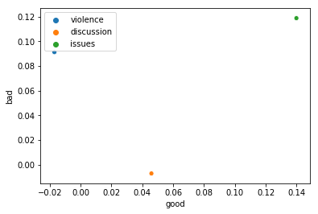

```python
sns.scatterplot(x='good', y='bad', data=pol_words_sim_2d, hue=pol_words_sim_2d.index)
```

- violence: less good, more bad
- discussion: less bad, more good
- issues: both bad and good

### Can we do this in an 1D scale?

(bad) --------------------?---- (good)

- First, let's create the vector for *bad-good* scale

```python
scale_bad_good = w2v_mod['good'] - w2v_mod['bad']
```

```python
# scale_bad_good
```

```python
cosine_similarity(w2v_mod['violence'], scale_bad_good)
```

```
-0.14428630471229553
```

```python
cosine_similarity(w2v_mod['discussion'], w2v_mod['good'] - w2v_mod['bad'])
```

```
0.0709114670753479
```

```python
cosine_similarity(w2v_mod['issues'], w2v_mod['good'] - w2v_mod['bad'])
```

```
0.028121288865804672
```

In summary, as displayed in Embedding Projector, words *violence*, *discussion*, and *issues* are located in the *bad-good* scale as following:

```python
pol_words_sim = pd.DataFrame([cosine_similarity(w2v_mod['violence'], w2v_mod['good'] - w2v_mod['bad']),
                              cosine_similarity(w2v_mod['discussion'], w2v_mod['good'] - w2v_mod['bad']),
                              cosine_similarity(w2v_mod['issues'], w2v_mod['good'] - w2v_mod['bad'])],
                             index=['violence', 'discussion', 'issues'], columns=['cos_sim'])
```

```python
pol_words_sim
```

|  | cos_sim |
| --- | --- |
| violence | -0.144286 |
| discussion | 0.070911 |
| issues | 0.028121 |

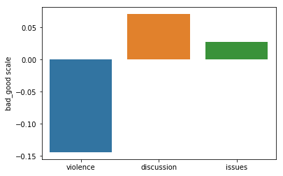

```python
ax = sns.barplot(x=pol_words_sim.index, y=pol_words_sim.cos_sim)
ax.set(ylabel="bad_good scale")
plt.show()
```

- *Violence* is more close to the *bad* end of the scale, while *discussion* is located towards the *good* end of the scale. *Issues* is located between those two words in the *bad-good* scale.

### Q9. (bonus) Select different scale and a set of words. How words are represented in the your suggested semantic scale?

- Why did you selected the particular scale and words? what's your interpretation?

(type in your response here)

```python
# put your code here
scale_cold_hot = w2v_mod['cold'] - w2v_mod['hot']
cosine_similarity(w2v_mod['Michigan'], scale_cold_hot)
cosine_similarity(w2v_mod['Florida'], scale_cold_hot)
cosine_similarity(w2v_mod['Atlanta'], scale_cold_hot)
```

```
-0.021011294797062874
```

```python
cold_hot_sim = pd.DataFrame([cosine_similarity(w2v_mod['Michigan'], w2v_mod['cold'] - w2v_mod['hot']),
                              cosine_similarity(w2v_mod['Florida'], w2v_mod['cold'] - w2v_mod['hot']),
                              cosine_similarity(w2v_mod['Atlanta'],w2v_mod['cold'] - w2v_mod['hot'])],
                             index=['Michigan', 'Florida', 'Atlanta'], columns=['cos_sim'])

cold_hot_sim
```

|  | cos_sim |
| --- | --- |
| Michigan | 0.114375 |
| Florida | 0.001170 |
| Atlanta | -0.021011 |

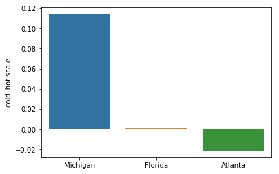

```python
ax = sns.barplot(x=cold_hot_sim.index, y=cold_hot_sim.cos_sim)
ax.set(ylabel="cold_hot scale")
plt.show()
```

Interestingly, if we create a cold-hot scale, and plot the results of three different states in the US ('Michigan','Florida','Atlanta'), we can tell that it makes sense since Michigan is the coldest state with higher latitube, yet even though Florida is more southerner than Atlanta, the result shows that Atlanta seems to be hotter than Florida in general.

- more to read about this method: http://bookworm.benschmidt.org/posts/2015-10-25-Word-Embeddings.html